# HOMEWORK 1

Jorge Barcia & Paloma Núñez

```r
# Clear environment
rm(list = ls())
# Set working directory
setwd("C:/Users/JORGE/OneDrive/Escritorio/apuntes/Aprendizaje estadistico/Trabajo1/trabajo")
```

# Data Source

This project uses the [Adult dataset from UCI](https://archive.ics.uci.edu/dataset/2/adult)

# Load Libraries

```r
library(corrplot)
library(dplyr)
library(factoextra)
library(gganimate)
library(GGally)
library(ggplot2)
library(gifski)
library(reshape2)
library(tidyr)
library(tidyverse)
```

# Load and clean the dataset.

Note that the dataset lacks a header, and missing values are represented as `?`. We add column names and this dataset have leading or trailing spaces which were a problem in some parts of our project therefore we needed to remove them

```r
#load data
data = read.csv("adult.data", header = FALSE, na.strings = " ?")
#lables
colnames(data) = c("age", "workclass", "fnlwgt", "education", "education_num", "marital_status", "occupation", "relationship",
                   "race", "sex", "capital_gain", "capital_loss", "hours_per_week",
                   "native_country", "income")
# Trim whitespace
data[] = lapply(data, function(x) if (is.character(x)) trimws(x) else x)
```

first lets check the structure of our data

```r
str(data)
```

```
## 'data.frame':    32561 obs. of  15 variables:
##  $ age           : int  39 50 38 53 28 37 49 52 31 42 ...
##  $ workclass     : chr  "State-gov" "Self-emp-not-inc" "Private" "Private" ...
##  $ fnlwgt        : int  77516 83311 215646 234721 338409 284582 160187 209642 45781 159449 ...
##  $ education     : chr  "Bachelors" "Bachelors" "HS-grad" "11th" ...
##  $ education_num : int  13 13 9 7 13 14 5 9 14 13 ...
##  $ marital_status: chr  "Never-married" "Married-civ-spouse" "Divorced" "Married-civ-spouse" ...
##  $ occupation    : chr  "Adm-clerical" "Exec-managerial" "Handlers-cleaners" "Handlers-cleaners" ...
##  $ relationship  : chr  "Not-in-family" "Husband" "Not-in-family" "Husband" ...
##  $ race          : chr  "White" "White" "White" "Black" ...
##  $ sex           : chr  "Male" "Male" "Male" "Male" ...
##  $ capital_gain  : int  2174 0 0 0 0 0 0 0 14084 5178 ...
##  $ capital_loss  : int  0 0 0 0 0 0 0 0 0 0 ...
##  $ hours_per_week: int  40 13 40 40 40 40 16 45 50 40 ...
##  $ native_country: chr  "United-States" "United-States" "United-States" "United-States" ...
##  $ income        : chr  "<=50K" "<=50K" "<=50K" "<=50K" ...
```

We can see that we have both numerical and categorical features. See also that we need to convert categorical columns to factors

```r
data = mutate(data, across(c(workclass, education, marital_status, occupation, relationship, race, sex, native_country,income)
                           ,as.factor))
```

We need some of the factor in an specific order therefore we specify levels for `education`.

```r
data$education = factor(data$education, levels = c("Preschool", "1st-4th", "5th-6th", "7th-8th","9th",
                                                   "10th", "11th", "12th", "HS-grad", "Some-college",
                                                   "Assoc-acdm",
                                                   "Assoc-voc", "Bachelors", "Masters", "Doctorate"))
```

Lets see a summary of our data to have a first glance of the Na Values and other important information

```r
summary(data)
```

```
##       age                   workclass         fnlwgt
##  Min.   :17.00   Private         :22696   Min.   :  12285
##  1st Qu.:28.00   Self-emp-not-inc: 2541   1st Qu.: 117827
##  Median :37.00   Local-gov       : 2093   Median : 178356
##  Mean   :38.58   State-gov       : 1298   Mean   : 189778
##  3rd Qu.:48.00   Self-emp-inc    : 1116   3rd Qu.: 237051
##  Max.   :90.00   (Other)         :  981   Max.   :1484705
##                  NA's            : 1836
##         education     education_num                 marital_status
##  HS-grad     :10501   Min.   : 1.00   Divorced             : 4443
##  Some-college: 7291   1st Qu.: 9.00   Married-AF-spouse    :   23
##  Bachelors   : 5355   Median :10.00   Married-civ-spouse   :14976
##  Masters     : 1723   Mean   :10.08   Married-spouse-absent:  418
##  Assoc-voc   : 1382   3rd Qu.:12.00   Never-married        :10683
##  (Other)     : 5733   Max.   :16.00   Separated            : 1025
##  NA's        :  576                   Widowed              :  993
##            occupation            relationship                   race
##  Prof-specialty : 4140   Husband       :13193   Amer-Indian-Eskimo:  311
##  Craft-repair   : 4099   Not-in-family : 8305   Asian-Pac-Islander: 1039
##  Exec-managerial: 4066   Other-relative:  981   Black             : 3124
##  Adm-clerical   : 3770   Own-child     : 5068   Other             :  271
##  Sales          : 3650   Unmarried     : 3446   White             :27816
##  (Other)        :10993   Wife          : 1568
##  NA's           : 1843
##      sex         capital_gain    capital_loss    hours_per_week
##  Female:10771   Min.   :    0   Min.   :   0.0   Min.   : 1.00
##  Male  :21790   1st Qu.:    0   1st Qu.:   0.0   1st Qu.:40.00
##                 Median :    0   Median :   0.0   Median :40.00
##                 Mean   : 1078   Mean   :  87.3   Mean   :40.44
##                 3rd Qu.:    0   3rd Qu.:   0.0   3rd Qu.:45.00
##                 Max.   :99999   Max.   :4356.0   Max.   :99.00
##
##        native_country    income
##  United-States:29170   <=50K:24720
##  Mexico       :  643   >50K : 7841
##  Philippines  :  198
##  Germany      :  137
##  Canada       :  121
##  (Other)      : 1709
##  NA's         :  583
```

## Handling NA Values Visualizing missing values in each column.

For seeing clearly the Number NA values and were are they located

```r
sum(is.na(data))
```

```
## [1] 4838
```

```r
sapply(data, function(x) sum(is.na(x)))
```

```
##            age      workclass         fnlwgt      education  education_num
##              0           1836              0            576              0
## marital_status     occupation   relationship           race            sex
##              0           1843              0              0              0
##   capital_gain   capital_loss hours_per_week native_country         income
##              0              0              0            583              0
```

Lets plot this info

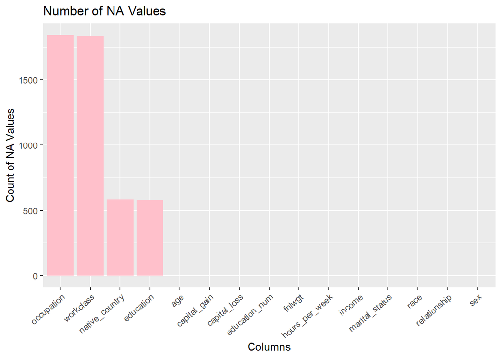

```r
na_counts = sapply(data, function(x) sum(is.na(x)))
aux_df = data.frame(Column = names(na_counts), NA_Count = na_counts)

ggplot(aux_df) +
  aes(x = reorder(Column, -NA_Count), y = NA_Count) +
  geom_bar(stat = "identity", fill = "pink") +
  labs(title = "Number of NA Values", x = "Columns", y = "Count of NA Values") +
  theme(axis.text.x = element_text(angle = 40, hjust = 1))
```

we can see that all of the NA values are in categorical features taking into acount that we have a fairly large dataset the best option is to omit these values as no substitution of these values will be satisfactory

```r
data = na.omit(data)
```

## Feature Engineering Creating additional categorical features.

`Age` is a useful statistic however for some parts of our project we are not interested in the exact age and the `age group` is much more useful similarly to age we have the case of `worked hours`, we are interested in seeing if overworking or part-timing has an influence. As the country of origin is EEUU we want to know if the `native born` have any advantage

```r
data = mutate(data, age_group = case_when(age < 25 ~ "Young", age >= 25 & age < 45 ~ "Adult",
                                          age >= 45 & age < 65 ~ "Middle-aged", age >= 65 ~ "Senior"))

data$age_group = as.factor(data$age_group)
data = mutate(data, work_hours_category = case_when(hours_per_week < 30 ~ "Part-time",
                                                    hours_per_week >= 30 & hours_per_week <= 40 ~ "Full-time",
                                                    hours_per_week > 40 ~ "Over-time"))
data$work_hours_category = as.factor(data$work_hours_category)

data$foreign_born = ifelse(data$native_country == 'United-States', 0, 1)
```

## Outlier Detection

**Using boxplots**

Now we will check for outliers that could ruin our analysis note that we can only have outliers in our numerical features

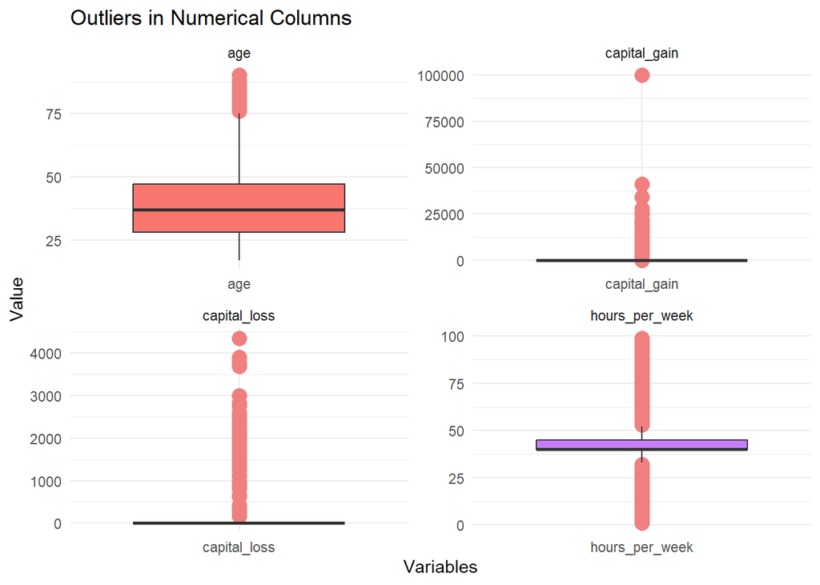

```r
numeric_cols = select(data, age, capital_gain, capital_loss, hours_per_week)
numeric_cols_long = pivot_longer(numeric_cols, cols = everything(), names_to = "Variable", values_to = "Value")
ggplot(numeric_cols_long) +
  aes(x = Variable, y = Value, fill = Variable) +
  geom_boxplot(outlier.color = "lightcoral", outlier.size = 4) +
  labs(title = "Outliers in Numerical Columns", x = "Variables", y = "Value") +
  theme_minimal() + theme(axis.text.x = element_text(hjust = 0.5), legend.position = "none")+
  facet_wrap(~ Variable, scales = "free")
```

**Using 3-sigma rule**

```r
detect_outliers_3sigma = function(x) {
  mean_x = mean(x, na.rm = TRUE)
  sd_x = sd(x, na.rm = TRUE)
  lower_bound = mean_x - 3 * sd_x
  upper_bound = mean_x + 3 * sd_x
  return(x < lower_bound | x > upper_bound)
}
outliers = data.frame(
  age = detect_outliers_3sigma(numeric_cols$age),
  capital_gain = detect_outliers_3sigma(numeric_cols$capital_gain),
  capital_loss = detect_outliers_3sigma(numeric_cols$capital_loss),
  hours_per_week = detect_outliers_3sigma(numeric_cols$hours_per_week)
)
outlier_counts = sapply(outliers, sum)
outlier_counts
```

```
##            age   capital_gain   capital_loss hours_per_week
##            116            173           1320            416
```

from the analysis we infer that `age` outliers are feasible 17-90 as min and max are acceptable values in `capital_gain` there’s a few top outliers with a value of 99,999$ this suggests that this is the maximum value accepted for the survey how ever as the real value is higher than this value we are going to leave these outliers. `capital_loss` does not have this problem and the value of the outliers is feasible `hours_per_week` is a especial case as 99 seem to be the maximum value similarly to what happens in capital_gain how ever here more than 99h a week seem inhumane, however as the dataset is from EEUU and from 1994 we can not rule out the possibility of these are true values and the subjet has two jobs

## Visualization Tools Exploring distributions and relationships.

# Age Distribution

we are going to start with the `age` visualization to see if our distribution is normal and if the +50k and -50k have te same distribution:

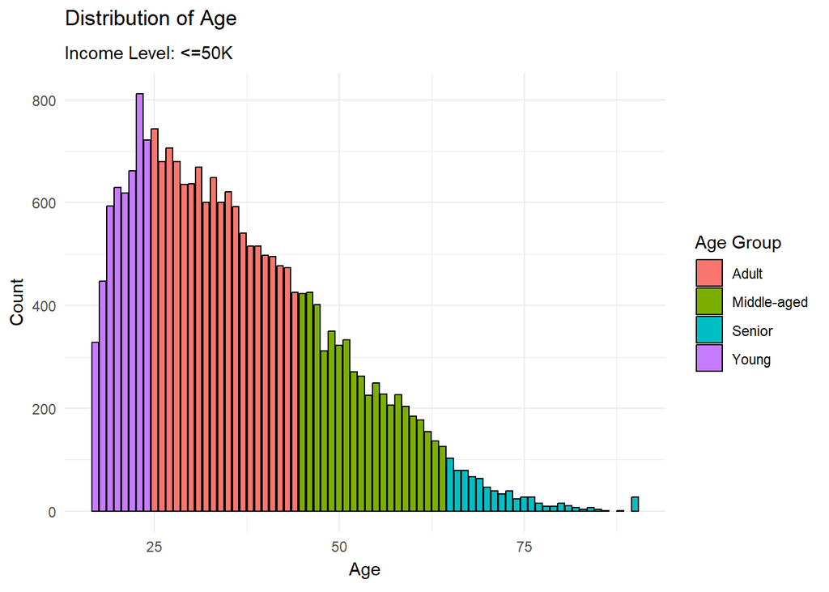

```r
p_age_dist = ggplot(data) +
  aes(x = age, fill = age_group) +
  geom_bar(color = "black") +
  labs(title = "Distribution of Age", x = "Age", y = "Count", fill = "Age Group") +
  theme_minimal()

# Animate by income level
p_age_dist + transition_states(income, transition_length = 0.5, state_length = 2) +
  labs(subtitle = "Income Level: {closest_state}")
```

we see that the `+50k` group have a geometrical distribution center around 40 years while the `-50k` is center around 25 and skewed to the right

## Income by Weekly Hours

one the questions we want to answer is that if the `hours worked per week` have an impact in the income and if this changes through out the age groups:

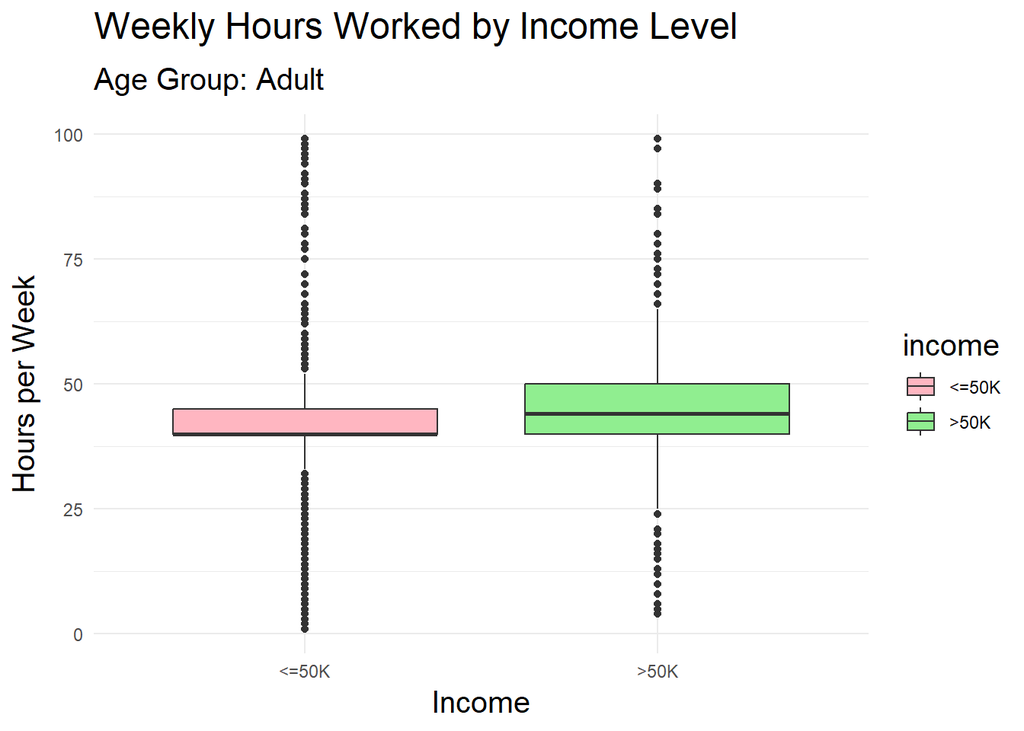

```r
p = ggplot(data) +
  aes(x = income, y = hours_per_week, fill = income) +
  geom_boxplot() +
  scale_fill_manual(values = c("lightpink", "lightgreen")) +
  labs(title = "Weekly Hours Worked by Income Level", x = "Income", y = "Hours per Week") +
  theme_minimal()+
  theme(title = element_text(size = 15))

p + transition_states(age_group, transition_length = 1.5, state_length = 1.5) +
    labs(subtitle = "Age Group: {closest_state}")
```

we see that both groups have similar means how ever the `+50k` group is more spread than the `-50K` and the differences max out in the senior group

## Income by Education Level

lets check if `education` have an impact

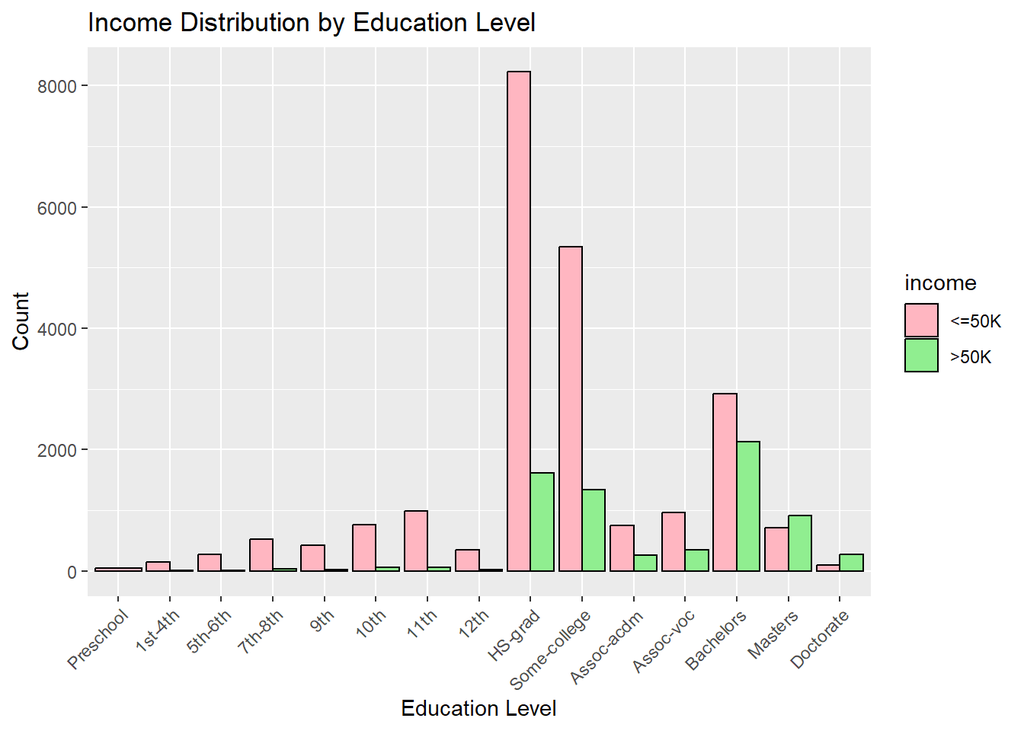

```r
ggplot(data, aes(x = education, fill = income)) + geom_bar(position = "dodge", color = "black") + scale_fill_manual(values = c("lightpink", "lightgreen")) + labs(title = "Income Distribution by Education Level", x = "Education Level", y = "Count") + theme(axis.text.x = element_text(angle = 45, hjust = 1))
```

from the graph we can see that the amount of people without `HS-graduation` that make more than `50K` are almost non-existing similarly `Bachelors degree` seems to be the high level of study that is significant as from that point if you have masters or doctorates there are more people that make more than `+50k` than people that don’t in that specific group

## Correlation analisis

Using a correlation plot `corrplot`, we visualize the strength and direction of these associations, we also added a heat map to see better what pairs are related

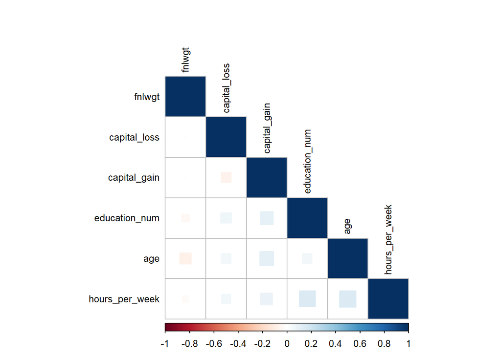

```r
numeric_data = select(data, age, fnlwgt, education_num, capital_gain, capital_loss, hours_per_week)

correlations = cor(numeric_data,method="spearman")
corrplot(correlations, number.cex = .9, method = "square",
         hclust.method = "ward", order = "FPC",
         type = "lower", tl.cex=0.8,tl.col = "black")
```

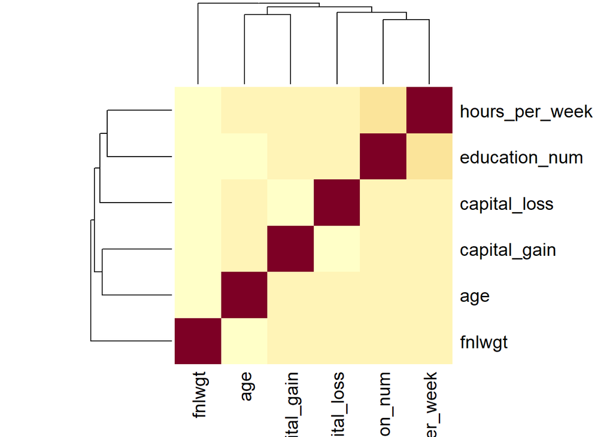

```r
heatmap(cor(numeric_data))
```

We see that there is not a strong correlation between any of the numerical variables, this is good for our final analysis as each one of them will give us different information to our analysis and not the same information over an over again as will be the case if we had really strong correlations for all the pairs therefore we avoid overlapping information and multicollinearity

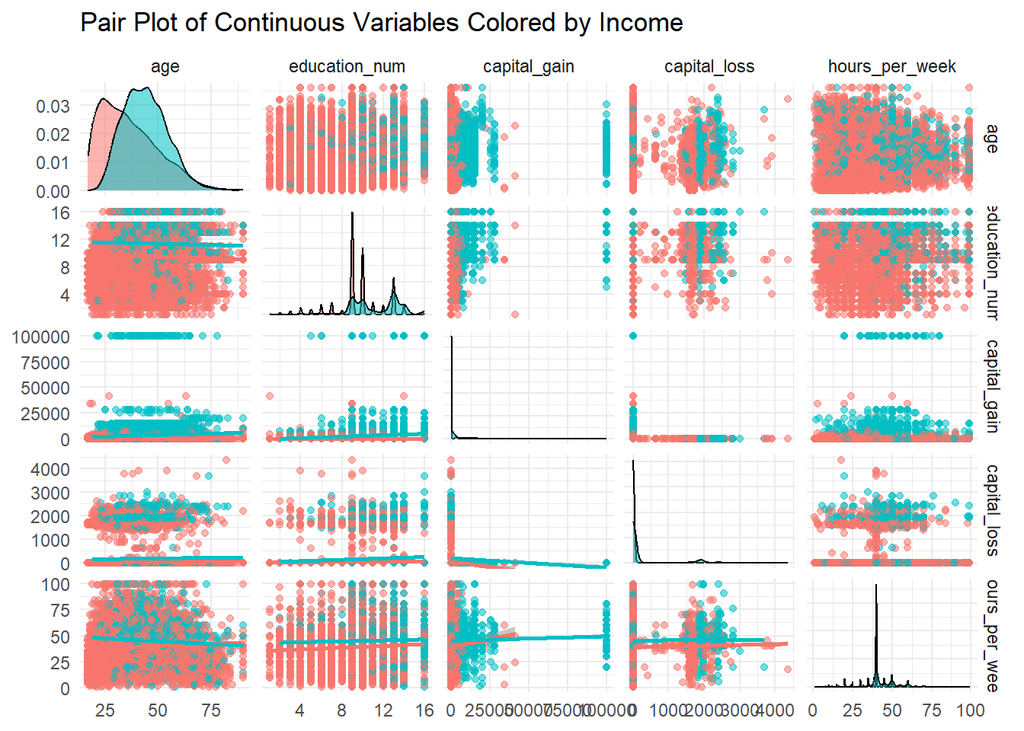

```r
ggpairs(data, columns = c("age", "education_num", "capital_gain", "capital_loss", "hours_per_week"),
        aes(color = income, alpha = 0.5),
        upper = list(continuous = "points"),
        lower = list(continuous = "smooth")) +
  theme_minimal() +
  labs(title = "Pair Plot of Continuous Variables Colored by Income")
```